# Homework 2

Lara Elena Abdünnur

07 05 2021

# Time Series Regression Model for Forecasting Mortgaged Sales

## 1. Introduction

### Required packages and Data

```r
library(ggplot2)
library(zoo)
library(openxlsx)
library(data.table)
library(forecast)
library(GGally)
data <- read.xlsx("C:/Users/VAİO/Desktop/data.xlsx",colNames = TRUE)
data$Date <- as.yearmon(data$Date)
sales<-as.data.table(data)
```

## 2. Analysis

### 2.1 Target Variable

First of all, we need to visualize the target variable to see if there is any pattern. Below you can find the line plot and the histogram of monthly mortgaged sales in Turkey.

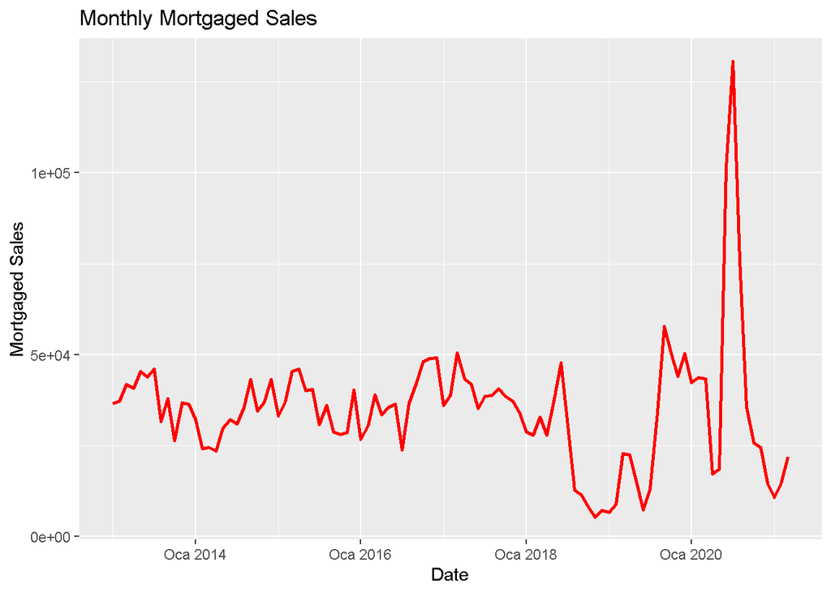

We can’t observe any particular pattern from the line plot. There are many ups and downs, but they are not a sign of seasonality component or cyclic pattern. Between 2013 and the start of 2018,plot has a stationary mean. However, there is a sharp decrease is mid-2018 and an abnormal increase in the summer of 2020. During pandemic, in 2020, public banks applied a discount to mortgage loan interest rates which acted as an incentive for people to buy mortgage loans.

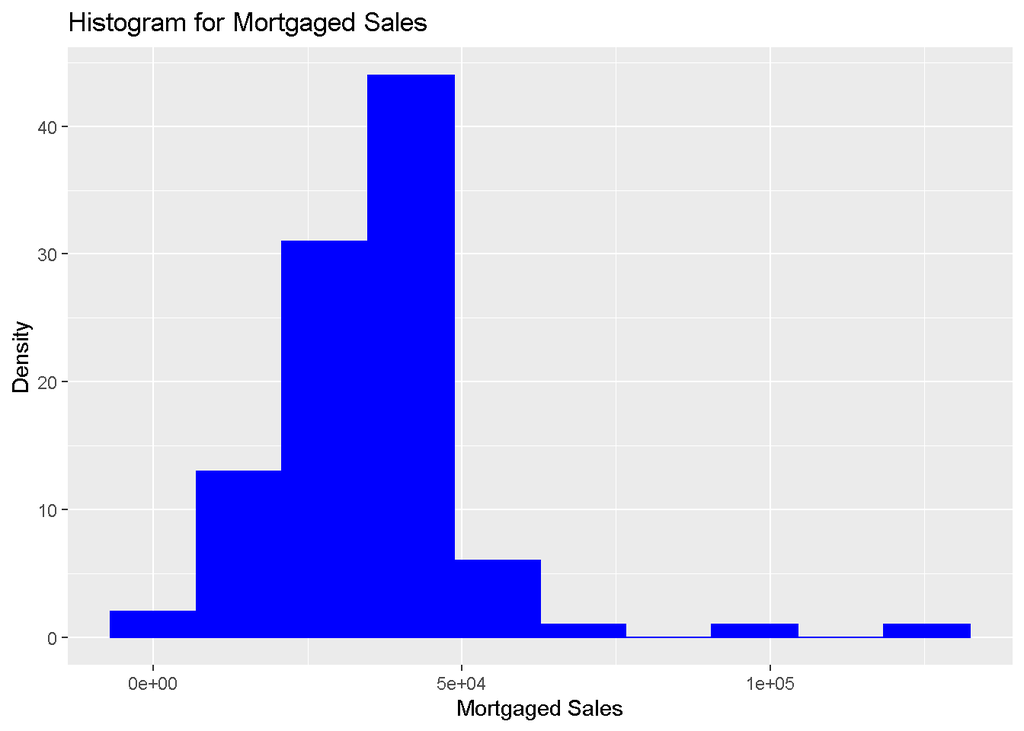

Depending on the histogram we can say that the mortgage sales are normally distributed, however there are some outliers. These outliers are the sharp increase in the summer of 2020 that we observed in the line plot.

### 2.2 Independent Variables

We must observe the related data sets to find the candidates that can be used as regressors for the time regression model. Below you can find the line plot of each data and the correlation of each variable with the mortgaged sales.

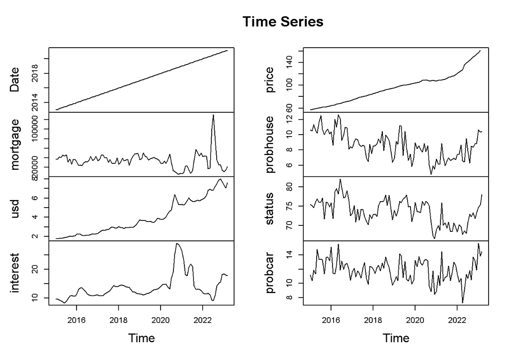

```r
#mortgage=Mortgaged Sales
#interest=Mortgage Interest Rates
#usd=USD Exchange Rate
#price=House Price Index
#status=Financial Status Of the Household
#probhouse=Probability of Buying a House
#probcar=Probability of Buying a Car
```

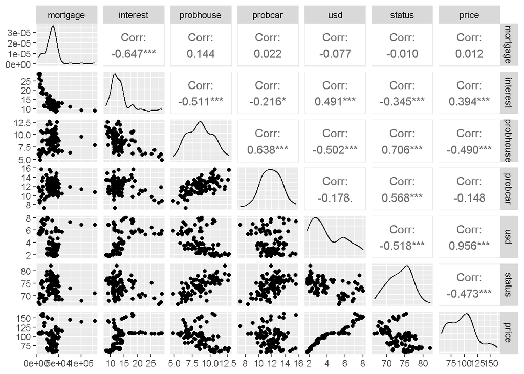

As you can see, mortgaged sales data has only one significant correlation, which is with the mortgage interest rates and they are negatively correlated. That’s why mortgage interest rates can be chosen as a regressor for the model.

## 3. Model Building

## 3.1 Trend and Seasonality Component

Now we can start to build our model. First of all let’s check if there is a trend in the mortgaged sales.

```
##
## Call:
## lm(formula = mortgage ~ trend, data = sales)
##
## Residuals:
##    Min     1Q Median     3Q    Max
## -28820  -8219    598   6558  97119
##
## Coefficients:
##             Estimate Std. Error t value Pr(>|t|)
## (Intercept) 36070.01    3495.54  10.319   <2e-16 ***
## trend         -27.12      60.70  -0.447    0.656
## ---
## Signif. codes:  0 '***' 0.001 '**' 0.01 '*' 0.05 '.' 0.1 ' ' 1
##
## Residual standard error: 17260 on 97 degrees of freedom
## Multiple R-squared:  0.002054,   Adjusted R-squared:  -0.008234
## F-statistic: 0.1997 on 1 and 97 DF,  p-value: 0.656
```

We can conclude that this is not a valid model due to high p-value. Also the r-squared value is really small and residual standard error is really high.

Let’s check if there is any seasonality component.

```r
fit2<-lm(mortgage~trend + as.factor(month),data=sales)
summary(fit2)
```

```
##
## Call:
## lm(formula = mortgage ~ trend + as.factor(month), data = sales)
##
## Residuals:
##    Min     1Q Median     3Q    Max
## -34931  -8740   -175   6972  88802
##
## Coefficients:
##                    Estimate Std. Error t value Pr(>|t|)
## (Intercept)        29358.48    6630.87   4.428 2.79e-05 ***
## trend                -26.44      62.30  -0.424   0.6723
## as.factor(month)2   1130.22    8324.90   0.136   0.8923
## as.factor(month)3   7715.21    8325.60   0.927   0.3567
## as.factor(month)4   3676.04    8582.91   0.428   0.6695
## as.factor(month)5   4701.85    8581.78   0.548   0.5852
## as.factor(month)6  14954.05    8581.10   1.743   0.0850 .
## as.factor(month)7  14967.11    8580.87   1.744   0.0847 .
## as.factor(month)8   9592.18    8581.10   1.118   0.2668
## as.factor(month)9   9114.62    8581.78   1.062   0.2912
## as.factor(month)10  4457.56    8582.91   0.519   0.6048
## as.factor(month)11  4787.12    8584.49   0.558   0.5785
## as.factor(month)12  6431.94    8586.52   0.749   0.4559
## ---
## Signif. codes:  0 '***' 0.001 '**' 0.01 '*' 0.05 '.' 0.1 ' ' 1
##
## Residual standard error: 17660 on 86 degrees of freedom
## Multiple R-squared:  0.07365,    Adjusted R-squared:  -0.0556
## F-statistic: 0.5698 on 12 and 86 DF,  p-value: 0.8606
```

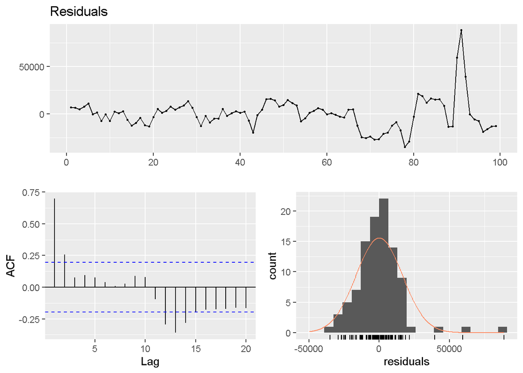

```
##
##  Breusch-Godfrey test for serial correlation of order up to 16
##
## data:  Residuals
## LM test = 77.812, df = 16, p-value = 4.116e-10
```

This is not a valid model as well, because of the same reasons. That’s why we don’t need to add the seasonality component. I will keep the trend variable to see if it improves with the other additions.

## 3.2 Mortgage Interest Rates

As I discussed earlier, we can use mortgage interest rates as a regressor because of its negative correlation with Mortgaged sales.

```r
fit3 <-lm(mortgage~interest+trend,data=sales)
summary(fit3)
```

```
##
## Call:
## lm(formula = mortgage ~ interest + trend, data = sales)
##
## Residuals:
##    Min     1Q Median     3Q    Max
## -32696  -5148   -990   3564  72145
##
## Coefficients:
##             Estimate Std. Error t value Pr(>|t|)
## (Intercept) 69539.58    4145.06  16.777  < 2e-16 ***
## interest    -3291.83     328.40 -10.024  < 2e-16 ***
## trend         209.21      48.73   4.293 4.21e-05 ***
## ---
## Signif. codes:  0 '***' 0.001 '**' 0.01 '*' 0.05 '.' 0.1 ' ' 1
##
## Residual standard error: 12130 on 96 degrees of freedom
## Multiple R-squared:  0.5124, Adjusted R-squared:  0.5022
## F-statistic: 50.44 on 2 and 96 DF,  p-value: 1.065e-15
```

This is a valid model as we can see from the small p-value. All of the regressors are valid as well. However, the residual standard error is quiet high and also the adjusted r-squared value is quiet low.

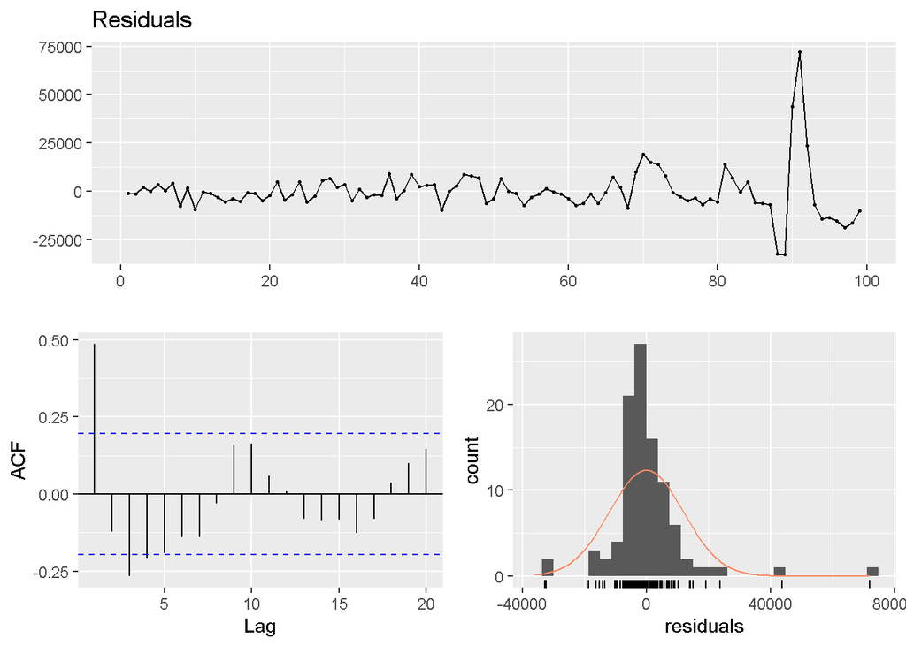

```
##
##  Breusch-Godfrey test for serial correlation of order up to 10
##
## data:  Residuals
## LM test = 52.372, df = 10, p-value = 9.738e-08
```

We can say that residuals are normally distributed. In the residuals plot there are abnormally large residuals, which model does not account for. This residuals are due to outliers. That’s why we need to include them into our model.

## 3.3 Outliers

First, we need to define the outliers and then add them to our model as a dummy variable.

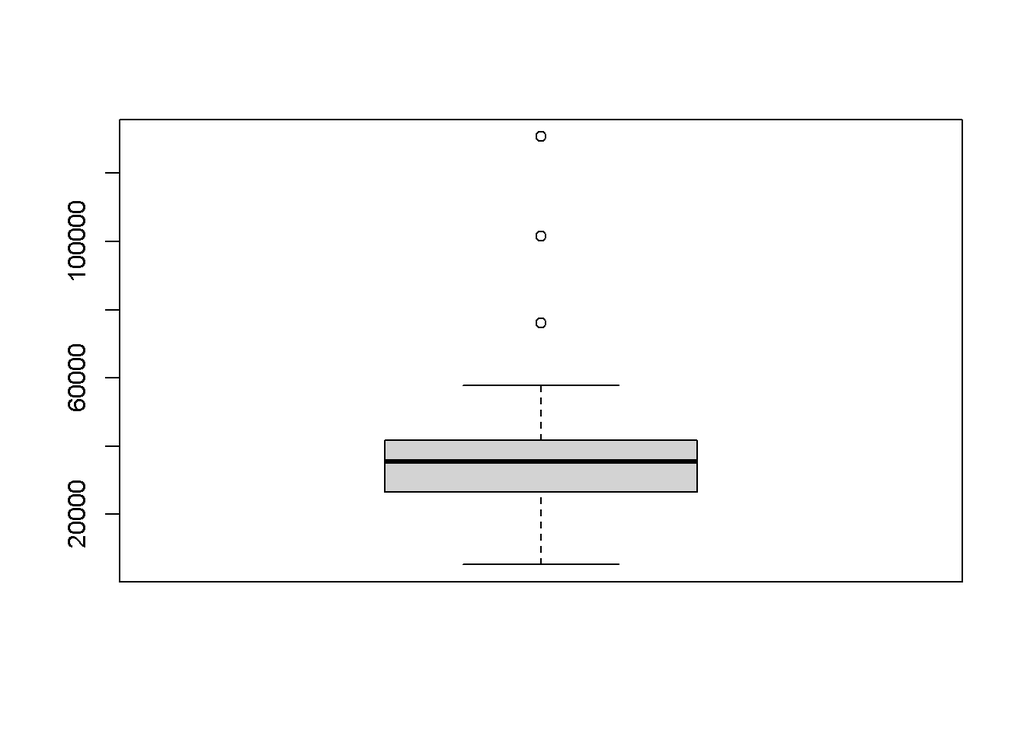

```
## [1] 101504 130721  76019
```

The outliers are observed in the summer of 2020, as we observed in the line plot.

```r
fit4 <- lm(mortgage~as.factor(outlier)+interest+trend,data=sales)
summary(fit4)
```

```
##
## Call:
## lm(formula = mortgage ~ as.factor(outlier) + interest + trend,
##     data = sales)
##
## Residuals:
##      Min       1Q   Median       3Q      Max
## -23763.5  -3833.1    -44.5   4010.3  26233.3
##
## Coefficients:
##                     Estimate Std. Error t value Pr(>|t|)
## (Intercept)         63292.91    2778.99   22.77   <2e-16 ***
## as.factor(outlier)1 57918.08    5131.34   11.29   <2e-16 ***
## interest            -2416.76     229.27  -10.54   <2e-16 ***
## trend                  58.27      34.70    1.68   0.0963 .
## ---
## Signif. codes:  0 '***' 0.001 '**' 0.01 '*' 0.05 '.' 0.1 ' ' 1
##
## Residual standard error: 7967 on 95 degrees of freedom
## Multiple R-squared:  0.7917, Adjusted R-squared:  0.7851
## F-statistic: 120.4 on 3 and 95 DF,  p-value: < 2.2e-16
```

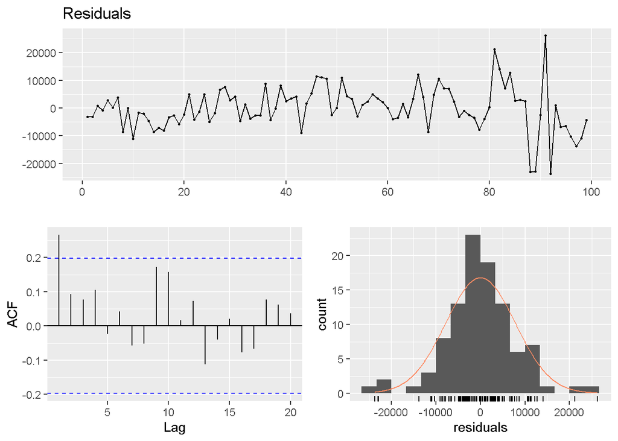

```
##
##  Breusch-Godfrey test for serial correlation of order up to 10
##
## data:  Residuals
## LM test = 16.408, df = 10, p-value = 0.08853
```

Addition of the outliers, significantly improved the model; residual standard error decreased to 7967 and adjusted r-squared increased to %78.51. Also, Residuals have a better normal distribution. Since it’s a sufficient model, I will choose this as my final model. However, please remark that this is not a perfect model. As we can see from the autocorrelation plot, lag 1 has a high value and still residuals do not perfectly follow the zero mean and constant variance assumption.

## 4. Model Validation

Here are some plots for evaluation of the final model.

## 4.1 Residuals Vs. Fitted

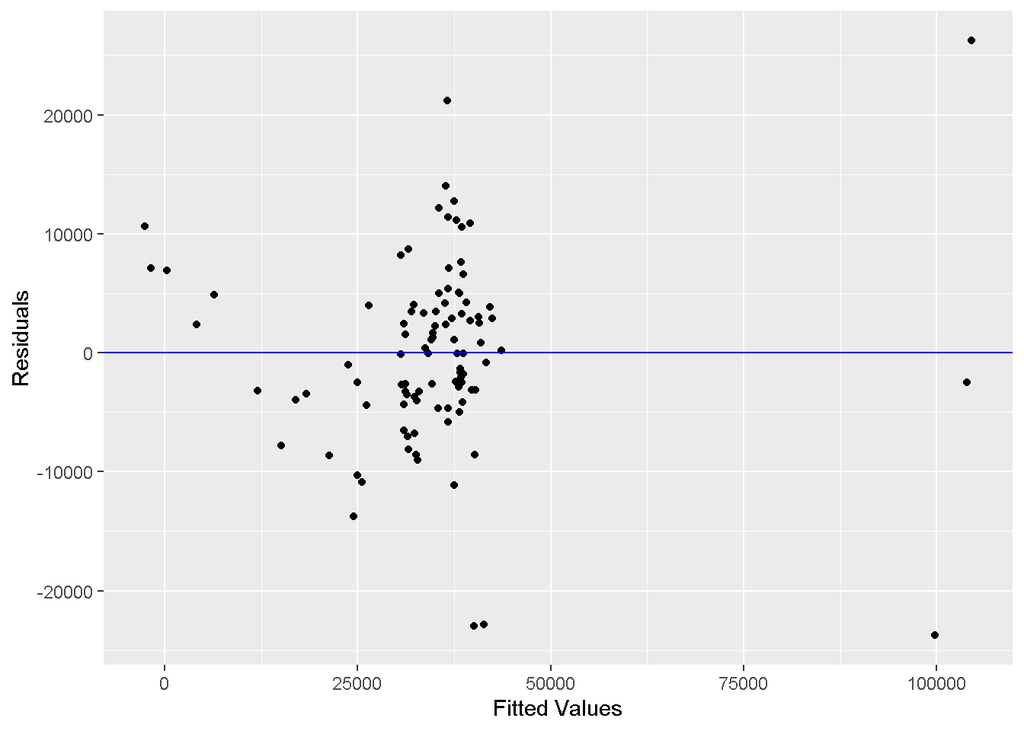

We can say that residuals are randomly distributed, but because of the outliers they don’t really follow the zero mean assumption.

## 4.2 Fitted Vs. Actual

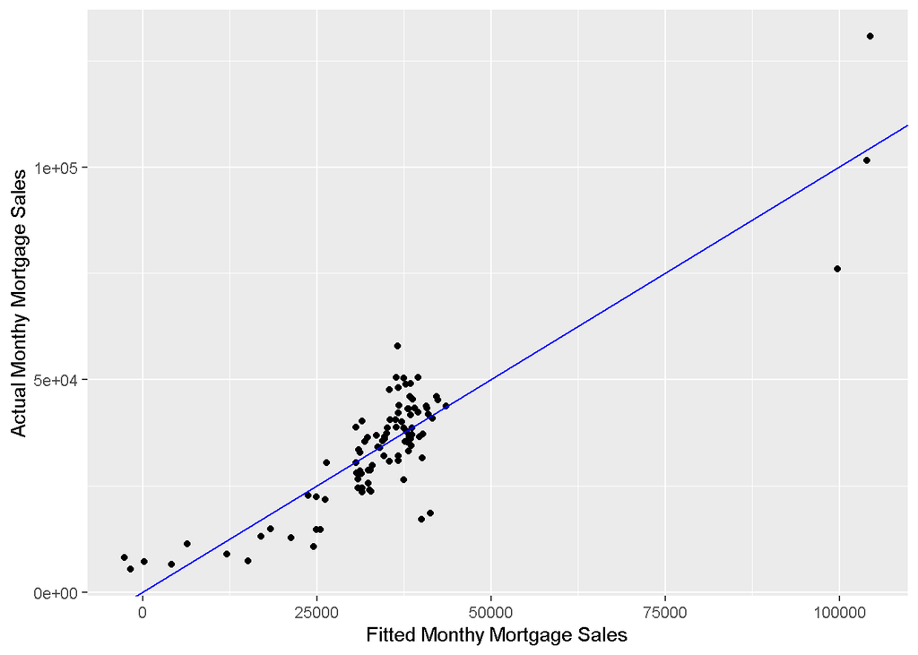

We can say that our model is acceptable since the fitted values are sufficiently explains the actual values

## 5. Forecast

The aim of this assignment was to forecast the mortgaged sales of April 2021. Since we don’t have data for the mortgage interest rate of April 2021, I take the average of the last 3 months as an estimate. Finally we get the following result for the forecast of April 2021.

```
##     1
## 25437
```

## 6. Conclusion

In this assignment, we tried to come up with a model for monthly mortgaged sales in Turkey and forecast the next month’s mortgages sales. We used trend, mortgage interest rates and outliers as regressors in our model. Finally we analyzed our model for validation. As you can see from the graph below, the model can be considered as an acceptable model since the forecasted values can explain the actual values.

### Forecasted Vs. Actual

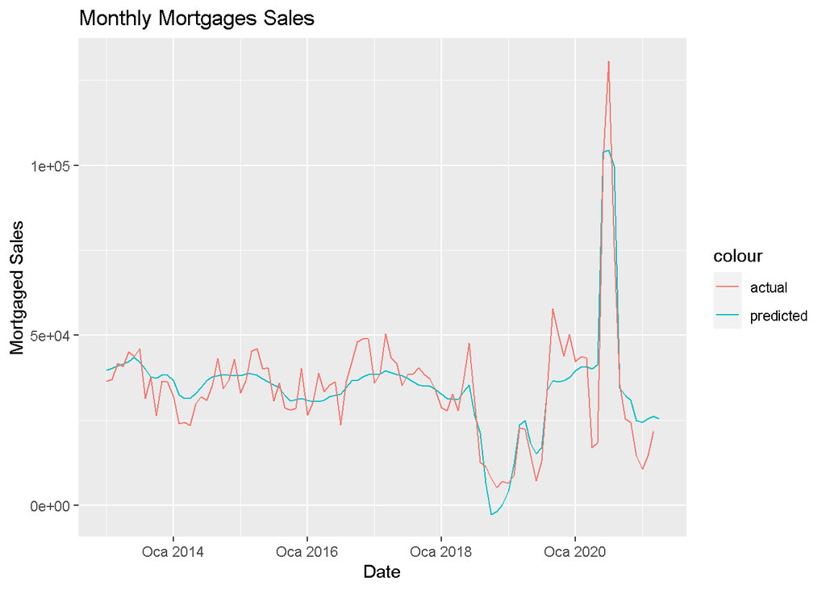